# Bayesian networks for human / mouse morphology comparison

# What

This repository contains the Bayesian network models underlying our paper, [‘Comparing basal dendrite branches in human and mouse hippocampal CA1 pyramidal neurons with Bayesian networks’](https://www.biorxiv.org/content/10.1101/2020.03.14.991828v1). There is detailed documentation on the models in the paper.

The models are [`bnlearn`](https://cran.r-project.org/web/packages/bnlearn/index.html) objects. You can use them for analyzing structure and conditional independencies as well as for probabilistic inference. The following is a plot of the Bayesian network for the morphology of terminal basal dendritic branches:

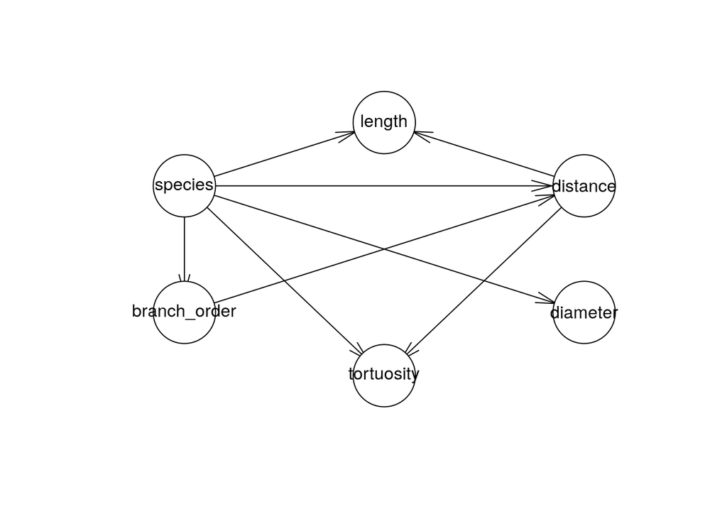

```r
load('models/bn_term.rdata')
bn <- bnlearn::bn.net(bn_term)
plot(bn)
```

The following shows that `length` is independent of `diameter` given `species` in the network.

```r
bnlearn::dsep('length', 'diameter', 'species', bn = bn)
```

```
## [1] TRUE
```

The repository contains 9 different Bayesian networks. Namely, we learned networks from three different subsets of our data: (a) from terminal branches alone; (b) from non-terminal branches alone; and (c) from both terminal and non-terminal branches. Within each data subset (that is, (a), (b), and (c)), we learned a separate Bayesian network model for each species as well as a combined Bayesian network model for both species.

# Install and load bnlearn

You will need the `bnlearn` R package.

```r
# install.packages('bnlearn')
```

```r
library(bnlearn)
```

# Load the models

The Bayesian networks are located in the `models` folder, as `R` objects. The `load()` function makes them available in memory. Their name is the name of their file, minus the extension (e.g., the model of human terminal branches is contained in object `bn_term_human`).

## Terminal branches

```r
load('models/bn_term.rdata') # bn_term
load('models/bn_term_human.rdata') # bn_term_human
load('models/bn_term_mouse.rdata') # bn_term_mouse
```

## Non-terminal branches

```r
load('models/bn_nonterm.rdata') # bn_nonterm
load('models/bn_nonterm_human.rdata') # bn_nonterm_human
load('models/bn_nonterm_mouse.rdata') # bn_nonterm_mouse
```

## All branches

```r
load('models/bn.rdata') # bn
load('models/bn_human.rdata') # bn_human
load('models/bn_mouse.rdata') # bn_mouse
```

# Using the models

The models are `bn.fit` objects (see bnlearn documentation) which means that they can readily be used for inference and prediction. For example, we may sample from and then plot the marginal distribution of branch diameter in terminal branches of both species:

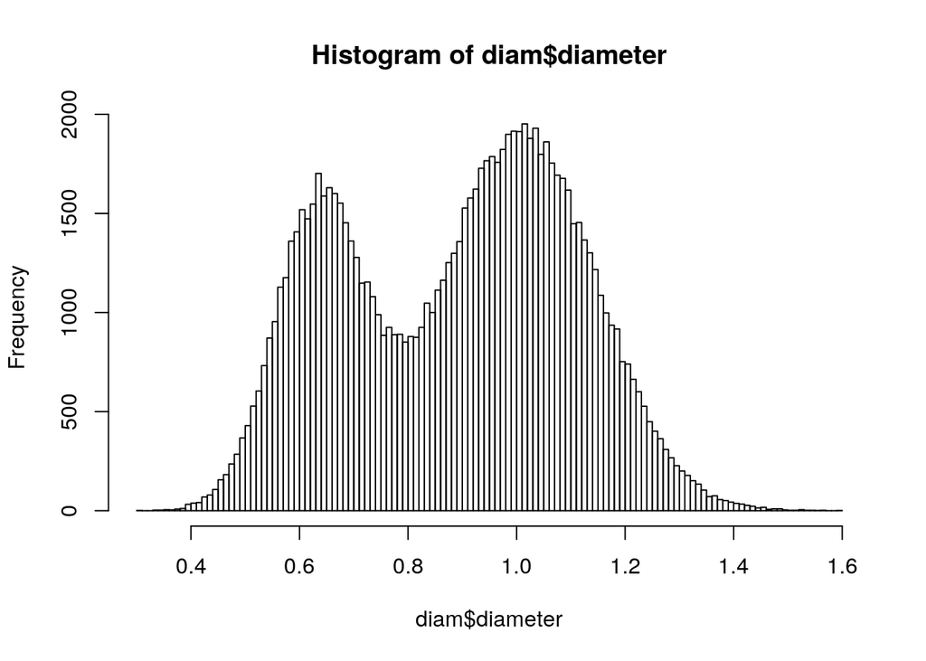

```r
diam <- cpdist(bn_term, nodes = 'diameter', evidence = TRUE, n = 1e5)
hist(diam$diameter, breaks = 100)
```

There are two modes because human branches are thicker than mouse ones.

If we want to analyze the networks (e.g., plot the structure, assess conditional independencies with the d-separation criterion) we need to convert the `bn.fit` object into a `bn` object, with `bn.net()`:

```r
bn <- bnlearn::bn.net(bn_term)
dsep(bn, 'diameter', 'length')
```

```
## [1] FALSE
```

```r
dsep(bn, 'diameter', 'length', 'species')
```

```
## [1] TRUE
```